## Endale B Altaye

Bowling Green State University

(419) 378 - 9131 ebaltay@bgsu.edu

## Sentiment Analysis of the Four Retail Stores (Amazon, Best Buy, Walmart and Ebay) using Twitter data

[figure not shown]

> im a 6 but in walmart im a 10

The sentiment analysis was done by extracting recent tweets related to each retail stores. 1000 tweets were extracted related to each and then the extracted tweets been filtered to make sure each tweet contains the name of the searched retail store.

```r
libs <- c("tm","ROAuth","twitteR","httr" ,"RCurl","stringr","plyr","dplyr","wordcloud", "lattice","scales","ggplot2")
lapply(libs,require, character.only= TRUE)
```

```r
consumer_key="deleted"
consumer_secret="deleted"
access_token="deleted"
access_secret=  "deleted"
setup_twitter_oauth(consumer_key,consumer_secret,access_token,access_secret )
pos=scan('positive-words.txt',what='character', comment.char=';')
neg=scan('negative-words.txt',what='character', comment.char=';')
```

### Sentiment Analysis Function

The Sentiment analysis algorithm that I used here is based on **Score values**. The sentiment of each words in each tweet were catagorized as either **Positive**, **Negative** or **Unknown** in comparision with the positive and negative words list provided on: http://www.cs.uic.edu/~liub/FBS/sentiment-analysis.html. The score value for each tweet is calculated as: $Score=TotalPostiveWords - TotalNegativeWords$ in each tweet. Then, tweets with positive value, (usualy greater than or equal to 2 (need siting)), would be assigned as tweets with a strong positive sentiment. On the other hand, tweets with score values less than or equal to -2, were catagorized as tweets with a strong negative sentiment. FYI, Some people are using the **naive Bayes trained classifier** rather than Scoring method to compute the sentiment analysis. Further reading could be found on `http://www.slideshare.net/DevSahu2/sentiment-analysis-using-naive-bayes-classifier-39784368`.

#### Sentiment Algorithm

```r
score_sentiment = function(sentences, pos_words, neg_words,.progress='none' ) # for laply function:
{
scores = laply(sentences,
function(sentence, pos_words, neg_words)
{
sentence = gsub("[[:punct:]]", " ", sentence) #- remove punctuation - using global substitute (gsub())
sentence = gsub("[[:cntrl:]]", " ", sentence) #- remove control characters (???)
sentence = gsub("[^[:graph:]]", " ", sentence) #- remove graphic characters
sentence = gsub("http\\w+", " ", sentence) # Remove links, just only http, (????)
sentence = gsub('\\d+', '', sentence) #- remove digits
sentence = gsub("@\\w+", " ", sentence) # remove @followed by word with no space
sentence = tolower(sentence)
word_list = str_split(sentence, "\\s+") #- split sentence into words with str_split (at stringr package)
words = unlist(word_list)
#- compare words to the dictionaries of positive & negative terms
pos_matches = match(words, pos_words)
neg_matches = match(words, neg_words)
pos_matches = !is.na(pos_matches)
neg_matches = !is.na(neg_matches)
#- final score
score = sum(pos_matches) - sum(neg_matches)
return(score)
}, pos_words, neg_words,.progress=.progress ) # for laply function .progress=
#- data frame with scores for each tweets
scores_df = data.frame(text=sentences, score=scores)
return(scores_df)
}
```

### Algorithm sanity check

```r
#Let's quickly test our score.sentiment() function and word lists with some sample sentences:
sample = c("Sentiment Analysis is Awesome, I Love it",
"Job search sucks, but plenty of time to do what I love doing, its fun.",
"BG is getting windy, its annoying and uncomfortable. #disaster #bad very bad  ")
result = score_sentiment(sample, pos, neg)
result
```

```r
 Check,  the value of result is (2 1 -5)
```

### Extracting Tweets

The information that I extracted from each tweets are:

- Tweet text using $getText()$
- Whether its a retweet or not using $isRetweet()$
- Number of retweets using $retweetCount()$
- Number of favourites using $favoriteCount()$

```r
Amazontweets = searchTwitter("Amazon", n=1000,resultType="recent", lang="en")
walmarttweets = searchTwitter("Walmart", n=1000,resultType="recent", lang="en")
ebaytweets = searchTwitter("Ebay", n=1000, resultType="recent",lang="en")
bestbuytweets = searchTwitter("Best Buy", n=1000, resultType="recent",lang="en")
```

```r
######## Upcoming codes are written in an explicit way############
############################Extracting the text from each tweet ##########
Amazon_txt = sapply(Amazontweets, function(x) x$getText())
walmart_txt = sapply(walmarttweets, function(x) x$getText())
ebay_txt = sapply(ebaytweets, function(x) x$getText())
bestbuy_txt = sapply(bestbuytweets, function(x) x$getText())

########################### Extracting whether its Retweet or not ##########
Amazon_isRetweet = sapply(Amazontweets, function(x) x$isRetweet)
walmart_isRetweet = sapply(walmarttweets, function(x) x$isRetweet)
ebay_isRetweet= sapply(ebaytweets, function(x) x$isRetweet)
bestbuy_isRetweet = sapply(bestbuytweets, function(x) x$isRetweet)
##########################

########################### Extracting retweetCount ########################
Amazon_retweetCount = sapply(Amazontweets, function(x) x$retweetCount)
walmart_retweetCount = sapply(walmarttweets, function(x) x$retweetCount)
ebay_retweetCount= sapply(ebaytweets, function(x) x$retweetCount)
bestbuy_retweetCount = sapply(bestbuytweets, function(x) x$retweetCount)
##########################

########################### Extracting favoriteCount #####################
Amazon_favoriteCount = sapply(Amazontweets, function(x) x$favoriteCount)
walmart_favoriteCount = sapply(walmarttweets, function(x) x$favoriteCount)
ebay_favoriteCount= sapply(ebaytweets, function(x) x$favoriteCount)
bestbuy_favoriteCount = sapply(bestbuytweets, function(x) x$favoriteCount)
##########################

nd = c(length(Amazon_txt), length(walmart_txt), length(ebay_txt),length(bestbuy_txt))
#- join texts
nd
#inspect(Amazon_txt[1:5])
retailStore = c(Amazon_txt, walmart_txt, ebay_txt, bestbuy_txt)
isRetweet=c(Amazon_isRetweet,walmart_isRetweet,ebay_isRetweet,bestbuy_isRetweet)
retweetCount=c(Amazon_retweetCount,walmart_retweetCount,ebay_retweetCount,bestbuy_retweetCount)
favoriteCount=c(Amazon_favoriteCount,walmart_favoriteCount,ebay_favoriteCount,bestbuy_favoriteCount)
```

```r
scores = score_sentiment(retailStore, pos, neg, .progress='text')
```

```r
#- add variables to data frame
scores$retailStore = as.factor(rep(c("Amazon", "Walmart", "Ebay", "Bestbuy"), nd))
scores$isRetweet=isRetweet
scores$retweetCount=retweetCount
scores$favoriteCount=favoriteCount
scores$very_pos = as.numeric(scores$score >= 2)
scores$very_neg = as.numeric(scores$score <=-2)
scores$neutral = as.numeric(scores$score >-2 & scores$score <2)
#View(scores)
```

## Filtering tweets

When we extract the tweets, there is a possibility of getting tweets which do not contain our searched word, **Walmart**, **Ebay**, **Best Buy** or **Amazon**. This might make our result a bit biased, thus its necessary to check and drop those which do not contain our searched word. **scoresfiltered** is the filtered version of **scores** data file. Note that this is done after computing the **score**, could be done earlier, which is the better way.

```r
scoresfiltered=filter(scores, grepl('Amazon |Walmart|Ebay|Best buy', text,ignore.case = TRUE))
#write.csv(scores,file="scores.csv")
#write.csv(scoresfiltered,file="scoresfiltered.csv")
```

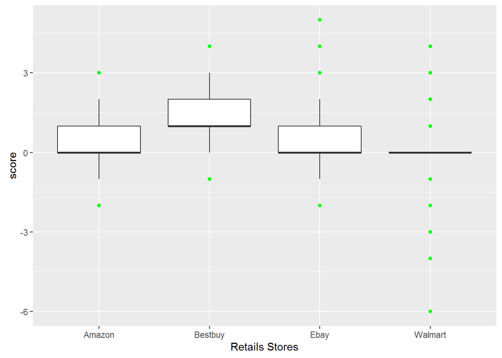

```r
# Extracted tweet are saved and retrieved just for convenience
scores=read.csv("C:/Users/selamina/Desktop/break/R/TextMiningTraining/TextTraining/scores.csv", comment.char="#")
scoresfiltered=read.csv("C:/Users/selamina/Desktop/break/R/TextMiningTraining/TextTraining/scoresfiltered.csv", comment.char="#")
ggplot(scoresfiltered, aes(factor(retailStore), score))+ geom_boxplot(outlier.colour = "green")+ labs(x="Retails Stores")
```

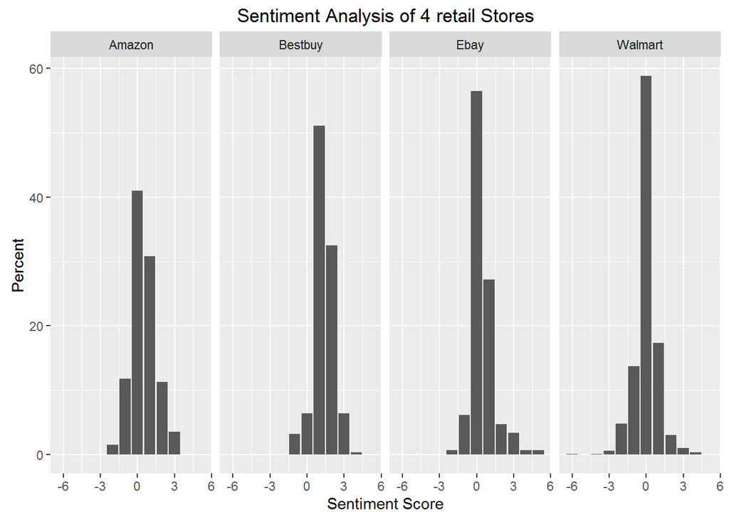

```r
ggplot(scoresfiltered, aes(score)) +
    geom_bar(aes(y = 100*(..count..)/tapply(..count..,..PANEL..,sum)[..PANEL..])) +
    facet_grid(~retailStore)+labs(y="Percent",x="Sentiment Score", title="Sentiment Analysis of 4 retail Stores")
```

As we can see from the four box plots and bar charts, **Best Buy** turn out to be the retail store with a higher positive sentiment than others. **Amazon** and **Ebay** have a pretty much similar, **Neutral** sentiment with a bit skewed to the positive sentiment side, in both cases. **Walmart** turn out to be the retail store with a very symmetric and **Neutral** sentiment.

```r
#- how many very positives and very negatives
numpos = sum(scoresfiltered$very_pos)
numneg = sum(scoresfiltered$very_neg)
global_score = round( 100 * numpos / (numpos + numneg) )
global_score
```

```
[1] 77
```

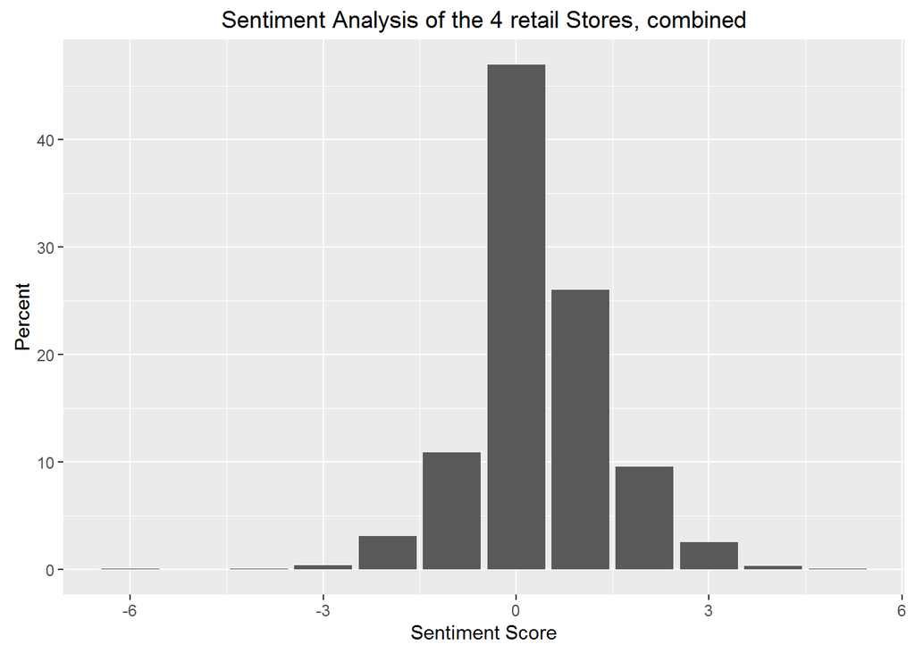

```r
ggplot(scoresfiltered, aes(score)) +
    geom_bar(aes(y = 100*(..count..)/tapply(..count..,..PANEL..,sum)[..PANEL..])) +
    labs(y="Percent",x="Sentiment Score",title="Sentiment Analysis of the 4 retail Stores, combined")
```

# The most retweeted tweet related to each retail store

The most retweeted tweet related to **Walmart** was `RT @vinnycrack: im a 6 but in walmart im a 10` of 14243 times.

The most retweeted tweet related to **Best buy** was `RT @MyNintendoNews: Link Takes Over Best Buy's Homepage https://t.co/4lAkNS8f0a https://t.co/kBhnLTHdD0` of 90 times.

```r
fevcount=scoresfiltered %>% dplyr::group_by(retailStore) %>% dplyr::arrange(-favoriteCount) %>% dplyr::select(favoriteCount,score,retweetCount)
slice(fevcount,1:3)
```

```
Source: local data frame [12 x 4]
Groups: retailStore [4]

   retailStore favoriteCount score retweetCount
        (fctr)         (int) (int)        (int)
1       Amazon             2     0            1
2       Amazon             2     2            0
3       Amazon             1     2            0
4      Bestbuy             7    -1            2
5      Bestbuy             4     2            4
6      Bestbuy             4     0            0
7         Ebay             2     0            1
8         Ebay             0     0          157
9         Ebay             0    -1            0
10     Walmart            26    -2            4
11     Walmart            12     0            1
12     Walmart            10     0            3
```

```r
retweetcount=scoresfiltered %>% dplyr::group_by(retailStore) %>% dplyr::arrange(-retweetCount) %>% dplyr::select(favoriteCount,score,retweetCount)
slice(retweetcount,1:3)
```

```
Source: local data frame [12 x 4]
Groups: retailStore [4]

   retailStore favoriteCount score retweetCount
        (fctr)         (int) (int)        (int)
1       Amazon             0     2         6738
2       Amazon             0     1         6619
3       Amazon             0     1         6538
4      Bestbuy             0     1           90
5      Bestbuy             0     2           37
6      Bestbuy             0     2           37
7         Ebay             0     0          157
8         Ebay             0     0           75
9         Ebay             0     0           51
10     Walmart             0     0        14243
11     Walmart             0     0        12359
12     Walmart             0     0        12359
```

```r
#Retweeted Percentage
scoresfiltered$isRetweet=as.factor(scoresfiltered$isRetweet)
PerRetweet=round(prop.table(table(scoresfiltered$retailStore,scoresfiltered$isRetweet),1)*100,2)
colnames(PerRetweet)=c("Not Retweeted (%)","Is Retweeted (%)")
PerRetweet
```

```
          Not Retweeted (%) Is Retweeted (%)
  Amazon              70.26            29.74
  Bestbuy             82.50            17.50
  Ebay                92.52             7.48
  Walmart             56.28            43.72
```

As we can see in the above table, around 44% of Walmart tweets are retweeted. Whereas, we can say its almost 7 % that Ebay related tweets are retweeted.

## Summary

I have extracted 1000 recent tweets related to each of **Amazon**, **Ebay**, **Walmart** and **Best Buy** for the sentiment analysis. According to the study,**Best Buy** attained a better positive sentiment than other retail stores. **Amazon** and **Ebay** have pretty much similar sentiment, slightly skewed to the positive side. **Walmart** retail store achieved a very **Neutral** sentiment. Interestingly, the most frequent retweet related to walmart is *im a 6 but in walmart im a 10* . In addition, Walmart related tweets have a higher percentage of being retweets.